# DSC 520 Statistics for Data Science Final Project - Florida Traffic Stops

Ambrose M Malagon Cordero

August 8, 2018

## Introduction

“What are the odds that you’re going to get pulled over by the police every time you get in the car?” - This question came about when a group coworkers and I witnessed another coworker (whom shall be referred to as “the driver”) get pulled over at our work location’s parking area. “Driver” stated that the Police officer tailed them all the way to work just to give a speeding ticket, remarked that “it was completely uncalled for”" and that they would fight the citation at court - which they lost. according to Police Report, “Driver”" was going 70 mph in area where the speed limit was 45 mph.

This incident was just one occurence of over 50,000 traffic stops that were potentially done by the United States Police on that given day (according to the Stanford Open Policing Project). It would be naive to assume that all of the 50,000 interactions which occured on that day were exactly the same as “Driver”’s. However, such a high number of traffic stops has made me wonder: why are so many people getting stopped on any given day?

## Problem Statement

As stated before, Driver went to court in an attempt to get the citation dropped but lost. The judge upheld the citation based on the information captured by the Police officer on that day. Driver believed that the data that was collected was not a true representation of the events - while these weren’t Driver’s exact words, the point that data captured by the Police Officer established the narrative (Driver was speeding and thus got a citation) serves as the trigger for the following questions:

- How many traffic stops occurred in the state of Florida at any given point?
- What is/are the most common type of traffic violations that occur within the state of Florida?
- What do the demographics for those drivers that get pulled over look like?
- Do we have enough information to create a model that will predict what type of outcome of the traffic stop?
- Can we use machine learning to classify the types of traffic stop citations?

## Methodology

For this study, I will be using the Stanford Open Policing Project – Florida data set, posted in Kaggle by the Stanford Open Policing Project (https://www.kaggle.com/stanford-openpolicing/stanford-open-policing-project-florida).

Libraries used for this initial data exploration:

- rmarkdown
- tidyr
- reshape2
- scales
- stringr
- lubridate
- dplyr
- ggplot2
- aod
- caTools
- pROC
- knitr
- pander
- e1071
- caret

**Importing the Data Set into R and preliminary cleaning:**

```r
stop.data <- read.csv("FL.csv")

dim(stop.data)
```

```
## [1] 5421446      28
```

By using the *dim* function, we note that the dataframe contains a total of 28 variables with 5,421,446 observations.

```r
head(stop.data)
```

|  | id | state | stop_date | stop_time | location_raw | county_name | county_fips | fine_grained_location | police_department | driver_gender | driver_age_raw | driver_age | driver_race_raw | driver_race | violation_raw | violation | search_conducted | search_type_raw | search_type | contraband_found | stop_outcome | is_arrested | officer_id | officer_gender | officer_age | officer_race | officer_rank | out_of_state |
| --- | --- | --- | --- | --- | --- | --- | --- | --- | --- | --- | --- | --- | --- | --- | --- | --- | --- | --- | --- | --- | --- | --- | --- | --- | --- | --- | --- | --- |
| 1 | FL-2010-000001 | FL | 2010-01-01 | 23:11 | SARASOTA | Sarasota County | 12115 |  | NA | F | 24 | 24 |  |  |  |  | NA |  |  | NA | Citation | NA | 1743 |  | NA |  | CPL | FALSE |
| 2 | FL-2010-000002 | FL | 2010-01-01 | 23:11 | SARASOTA | Sarasota County | 12115 |  | NA |  | NA | NA | W | White | SEATBELT (DRIVER) | Seat belt | FALSE | NO SEARCH REQUESTED |  | FALSE | Citation | FALSE | 1743 | M | NA |  |  | NA |
| 3 | FL-2010-000003 | FL | 2010-01-06 | 16:14 | DUVAL | Duval County | 12031 | JACKSONVILLE | NA | F | 23 | 23 | W | White | SPEED | Speeding | FALSE | NO SEARCH REQUESTED |  | FALSE | Citation | FALSE | 2138 | M | 31 | Black | TROOPER | TRUE |
| 4 | FL-2010-000004 | FL | 2010-01-08 | 19:39 | DUVAL | Duval County | 12031 | JACKSONVILLE | NA | F | 45 | 45 | W | White | CARELESS DRIVING\|DUI | DUI,Safe movement | FALSE | NO SEARCH REQUESTED |  | FALSE | Misdemeanor Arrest | TRUE | 2595 | M | 29 | White | TPR | FALSE |
| 5 | FL-2010-000005 | FL | 2010-01-11 | 11:56 | ST. LUCIE | St. Lucie County | 12111 |  | NA | M | 41 | 41 | W | White | DRIVING WHILE LICENSE SUSPENDED / REVOKED\|SPEED | License,Speeding | FALSE | NO SEARCH REQUESTED |  | FALSE | Misdemeanor Arrest | TRUE | 2586 | M | 26 | White | TPR. | FALSE |
| 6 | FL-2010-000006 | FL | 2010-01-12 | 02:00 | HERNANDO | Hernando County | 12053 |  | NA | M | 24 | 24 | B | Black |  |  | NA |  |  | NA | Citation | NA | 708 |  | NA |  | CORPORAL | FALSE |

Looking at the first 6 rows of our data frame, we notice that several observations have a hard coded *NA* value or have been left blank, which leads me to believe that these are being handled as two different value types:

```r
as.data.frame(colSums(stop.data ==""))
```

|  | colSums(stop.data == "") |
| --- | --- |
| id | 0 |
| state | 0 |
| stop_date | 0 |
| stop_time | 214 |
| location_raw | 1 |
| county_name | 826 |
| county_fips | NA |
| fine_grained_location | 4186487 |
| police_department | NA |
| driver_gender | 1316775 |

[output cut: 18 more lines]

```r
as.data.frame(colSums(is.na(stop.data)))
```

|  | colSums(is.na(stop.data)) |
| --- | --- |
| id | 0 |
| state | 0 |
| stop_date | 0 |
| stop_time | 0 |
| location_raw | 0 |
| county_name | 0 |
| county_fips | 826 |
| fine_grained_location | 0 |
| police_department | 5421446 |
| driver_gender | 0 |

[output cut: 18 more lines]

By using the the *mutate* function, we can turn all of the blank values into NA’s:

```r
stop.dataR2 <- stop.data %>% mutate_all(na_if,"")
```

We inspect this new dataframe to ensure that all *blank* values have been succesfully converted to *NA*:

```r
as.data.frame(colSums(stop.dataR2 ==""))
```

|  | colSums(stop.dataR2 == "") |
| --- | --- |
| id | 0 |
| state | 0 |
| stop_date | 0 |
| stop_time | NA |
| location_raw | NA |
| county_name | NA |
| county_fips | NA |
| fine_grained_location | NA |
| police_department | NA |
| driver_gender | NA |

[output cut: 18 more lines]

```r
as.data.frame(colSums(is.na(stop.dataR2)))
```

|  | colSums(is.na(stop.dataR2)) |
| --- | --- |
| id | 0 |
| state | 0 |
| stop_date | 0 |
| stop_time | 214 |
| location_raw | 1 |
| county_name | 826 |
| county_fips | 826 |
| fine_grained_location | 4186487 |
| police_department | 5421446 |
| driver_gender | 1316775 |

[output cut: 18 more lines]

**Selecting a sample size:**

We can use the following formula to determine an appropriate sample size:

Necessary Sample Size = (Z-score)2 * StdDev *(1-StdDev) / (margin of error)

Below are the z-scores for the most common confidence levels:

- 90% – Z Score = 1.645
- 95% – Z Score = 1.96
- 99% – Z Score = 2.576

Because of the large sample size, I want to look at the 99% confidence interval with a 1% margin of error. In order to do this calculation, I used the following function (source: http://news.mrdwab.com/post/sample-size-calculator/):

```r
sample.size.table = function(margin=.5, c.interval=.05, population) {
  z.val=c(1.281551565545, 1.644853626951, 1.959963984540,
          2.326347874041, 2.575829303549, 2.807033768344,
          3.090232306168, 3.290526731492, 3.890591886413)
  ss = (z.val^2 * margin * (1-margin))/(c.interval^2)
  p.ss = ss/(1 + ((ss-1)/population))
  c.level = c("80%","90%","95%","98%","99%",
              "99.5%","99.8%","99.9%","99.99%")
  results = data.frame(c.level, round(p.ss, digits = 0))
  names(results) = c("Confidence Level", "Sample Size")
  METHOD = c("Suggested sample sizes at different confidence levels")
  moe = paste((c.interval*100), "%", sep="")
  resp.dist = paste((margin*100),"%", sep="")
  pre = structure(list(Population=population,
                       "Margin of error" = moe,
                       "Response distribution" = resp.dist,
                       method = METHOD),
                  class = "power.htest")
  print(pre)
  print(results)
}

sample.size.table(0.5, 0.01, 5421446)
```

```
##
##      Suggested sample sizes at different confidence levels
##
##            Population = 5421446
##       Margin of error = 1%
## Response distribution = 50%
##
##   Confidence Level Sample Size
## 1              80%        4103
## 2              90%        6755
## 3              95%        9587
## 4              98%       13496
## 5              99%       16537
## 6            99.5%       19627
## 7            99.8%       23769
## 8            99.9%       26934
## 9           99.99%       37579
```

This provides our final sample size: 16,537 observations. Now we select the observations from our data set:

```r
stop.dataR3 <- stop.dataR2[sample(nrow(stop.dataR2),16537),]

dim(stop.dataR3)
```

```
## [1] 16537    28
```

*Notice* - I am not excluding any NA values with the sample selection. Doing so would potentially skew the results the analysis. Rather than omitting these, we can use data transformation to provide more context to our results by asking the following questions:

- Which variables are more likely to be ommited during an interaction?
- What type of outcomes have more variables ommitted?

The following table will assist us with assessing the situation:

```r
na.data <- as.data.frame(colSums(is.na(stop.dataR3)))
na.data
```

|  | colSums(is.na(stop.dataR3)) |
| --- | --- |
| id | 0 |
| state | 0 |
| stop_date | 0 |
| stop_time | 1 |
| location_raw | 0 |
| county_name | 1 |
| county_fips | 1 |
| fine_grained_location | 12760 |
| police_department | 16537 |
| driver_gender | 4016 |

[output cut: 18 more lines]

* Variables greater *NA* 5,000 observations - Exclude these variables from the final data set. * Variables with 10 or less *NA* observations - Leave these observations in the data set, with the understanding that they could be removed if they ultimately prove to be influencing outliers. * Variables with less than 5,000 but greater than 10 *NA* observations - Create new variables to account if they were captured during the interaction or not.

```r
driver_gender_captured <- ifelse(is.na(stop.dataR3$driver_gender), "FALSE", "TRUE")
driver_age_raw_captured <- ifelse(is.na(stop.dataR3$driver_age_raw), "FALSE", "TRUE")
driver_age_captured <- ifelse(is.na(stop.dataR3$driver_age), "FALSE", "TRUE")
driver_age_raw_captured <- ifelse(is.na(stop.dataR3$driver_age_raw), "FALSE", "TRUE")
driver_race_raw_captured <- ifelse(is.na(stop.dataR3$driver_race_raw), "FALSE", "TRUE")
driver_race_captured <- ifelse(is.na(stop.dataR3$driver_race), "FALSE", "TRUE")
driver_violation_raw_captured <- ifelse(is.na(stop.dataR3$violation_raw), "FALSE", "TRUE")
driver_violation_captured <- ifelse(is.na(stop.dataR3$violation), "FALSE", "TRUE")
stop_outcome_captured <- ifelse(is.na(stop.dataR3$stop_outcome), "FALSE", "TRUE")
is_arrested_captured <- ifelse(is.na(stop.dataR3$is_arrested), "FALSE", "TRUE")
officer_gender_captured <- ifelse(is.na(stop.dataR3$officer_gender), "FALSE", "TRUE")
officer_age_captured <- ifelse(is.na(stop.dataR3$officer_age), "FALSE", "TRUE")
officer_race_captured <- ifelse(is.na(stop.dataR3$officer_race), "FALSE", "TRUE")
officer_rank_captured <- ifelse(is.na(stop.dataR3$officer_rank), "FALSE", "TRUE")
out_of_state_captured <- ifelse(is.na(stop.dataR3$out_of_state), "FALSE", "TRUE")
```

**Data Transformation**

Starting with the *Officer Rank*, we need to strip down the various permutations (spelling typos and different naming conventions) for these:

```r
officer_rank_stream <- str_remove(stop.dataR3$officer_rank, "[./]")

officer_rank_stream[officer_rank_stream == 'CORP'| officer_rank_stream == 'CORPORL'|officer_rank_stream =='CPL'] <- 'CORPORAL'
officer_rank_stream[officer_rank_stream == 'CAPT'| officer_rank_stream == 'CPT'] <- 'CAPTAIN'
officer_rank_stream[officer_rank_stream == 'LT'] <- 'LIEUTENANT'
officer_rank_stream[officer_rank_stream == 'MSR TRP'|
                      officer_rank_stream == 'MST TRP.'|
                      officer_rank_stream == 'MSTPR'|
                      officer_rank_stream == 'MSTR'|
                      officer_rank_stream == 'MSTR TPR'|
                      officer_rank_stream == 'MSTR TPR.'|
                      officer_rank_stream == 'MSTR/TPR.'|
                      officer_rank_stream == 'MSR TRP'|
                      officer_rank_stream == 'MSTRTPR.'|
                      officer_rank_stream == 'MTPR'|
                      officer_rank_stream == 'MTPR.'|
                      officer_rank_stream == 'MTRP'|
                      officer_rank_stream == 'MTROOPER'] <- 'MASTER TPR'
officer_rank_stream[officer_rank_stream == 'MCPL' | officer_rank_stream == 'MST CPL' ] <- 'MASTER CPL'
officer_rank_stream[officer_rank_stream == 'SR TPR.' |
                      officer_rank_stream == 'SRTPR.' |
                      officer_rank_stream == 'STPR.'] <- 'SR TRP'
officer_rank_stream[officer_rank_stream == 'TRP' |
                      officer_rank_stream == 'TRR' |
                      officer_rank_stream == 'TPR'] <- 'TROOPER'
officer_rank_stream[officer_rank_stream == 'SGT'] <- 'SERGEANT'
officer_rank_stream[officer_rank_stream == 'SSERGEANT'] <- 'STAFF SERG'

pander(table(officer_rank_stream))
```

Table continues below

| CAPTAIN | CORPORAL | LIEUTENANT | M SGT | M CPL. | MAJOR | MASTER CPL |
| --- | --- | --- | --- | --- | --- | --- |
| 56 | 730 | 166 | 1 | 1 | 4 | 3 |

Table continues below

| MASTER SGT | MASTER TPR | MASTR CPL | MSGT | MST TRP | MSTR CPL | OFFICER |
| --- | --- | --- | --- | --- | --- | --- |
| 1 | 41 | 1 | 8 | 2 | 22 | 308 |

Table continues below

| PILOT | SERGEANT | SFC | SR TRP | STAFF SERG | STAFF SGT | STPR | TFC |
| --- | --- | --- | --- | --- | --- | --- | --- |
| 3 | 857 | 4 | 3 | 5 | 1 | 3 | 10 |

| TPR SPC | TROOPER | TROOPER RE | TRPR |
| --- | --- | --- | --- |
| 1 | 10273 | 13 | 1 |

Up next: the *violation* variable.

```r
violation_rawsl <- as.character(stop.dataR3$violation)

violation_rawsl[ violation_rawsl == 'DUI,Equipment' |
                   violation_rawsl == 'DUI,Equipment,License' |
                   violation_rawsl == 'DUI,Equipment,License,Registration/plates,Truck' |
                   violation_rawsl == 'DUI,Equipment,Other' |
                   violation_rawsl == 'DUI,Equipment,Safe movement' |
                   violation_rawsl == 'DUI,Equipment,Truck' |
                   violation_rawsl == 'DUI,License' |
                   violation_rawsl == 'DUI,License,Safe movement' |
                   violation_rawsl == 'DUI,License,Seat belt' |
                   violation_rawsl == 'DUI,License,Speeding' |
                   violation_rawsl == 'DUI,Lights' |
                   violation_rawsl == 'DUI,Other' |
                   violation_rawsl == 'DUI,Other (non-mapped)' |
                   violation_rawsl == 'DUI,Other,Speeding' |
                   violation_rawsl == 'DUI,Safe movement' |
                   violation_rawsl == 'DUI,Safe movement,Seat belt' |
                   violation_rawsl == 'DUI,Safe movement,Speeding' |
                   violation_rawsl == 'DUI,Seat belt' |
                   violation_rawsl == 'DUI,Seat belt,Speeding' |
                   violation_rawsl == 'DUI,Speeding'] <- 'DUI'

violation_rawsl[  violation_rawsl == 'Equipment,License' |
                    violation_rawsl == 'Equipment,License,Other' |
                    violation_rawsl == 'Equipment,License,Other (non-mapped)' |
                    violation_rawsl == 'Equipment,License,Other,Paperwork' |
                    violation_rawsl == 'Equipment,License,Other,Paperwork,Seat belt' |
                    violation_rawsl == 'Equipment,License,Paperwork' |
                    violation_rawsl == 'Equipment,License,Paperwork,Safe movement' |
                    violation_rawsl == 'Equipment,License,Paperwork,Safe movement,Seat belt' |
                    violation_rawsl == 'Equipment,License,Registration/plates' |
                    violation_rawsl == 'Equipment,License,Safe movement' |
                    violation_rawsl == 'Equipment,License,Seat belt' |
                    violation_rawsl == 'Equipment,License,Seat belt,Speeding' |
                    violation_rawsl == 'Equipment,License,Speeding' |
                    violation_rawsl == 'Equipment,License,Truck' |
                    violation_rawsl == 'Equipment,Lights' |
                    violation_rawsl == 'Equipment,Lights,Speeding' |
                    violation_rawsl == 'Equipment,Other' |
                    violation_rawsl == 'Equipment,Other (non-mapped)' |
                    violation_rawsl == 'Equipment,Other,Paperwork' |
                    violation_rawsl == 'Equipment,Other,Paperwork,Speeding' |
                    violation_rawsl == 'Equipment,Other,Paperwork,Speeding,Truck' |
                    violation_rawsl == 'Equipment,Other,Registration/plates' |
                    violation_rawsl == 'Equipment,Other,Safe movement' |
                    violation_rawsl == 'Equipment,Other,Seat belt' |
                    violation_rawsl == 'Equipment,Other,Speeding' |
                    violation_rawsl == 'Equipment,Other,Truck' |
                    violation_rawsl == 'Equipment,Paperwork' |
                    violation_rawsl == 'Equipment,Paperwork,Registration/plates' |
                    violation_rawsl == 'Equipment,Paperwork,Registration/plates,Speeding' |
                    violation_rawsl == 'Equipment,Paperwork,Registration/plates,Truck' |
                    violation_rawsl == 'Equipment,Paperwork,Safe movement' |
                    violation_rawsl == 'Equipment,Paperwork,Seat belt' |
                    violation_rawsl == 'Equipment,Paperwork,Seat belt,Truck' |
                    violation_rawsl == 'Equipment,Paperwork,Speeding' |
                    violation_rawsl == 'Equipment,Paperwork,Speeding,Truck' |
                    violation_rawsl == 'Equipment,Paperwork,Truck' |
                    violation_rawsl == 'Equipment,Registration/plates' |
                    violation_rawsl == 'Equipment,Registration/plates,Safe movement' |
                    violation_rawsl == 'Equipment,Registration/plates,Seat belt' |
                    violation_rawsl == 'Equipment,Registration/plates,Speeding' |
                    violation_rawsl == 'Equipment,Registration/plates,Truck' |
                    violation_rawsl == 'Equipment,Safe movement' |
                    violation_rawsl == 'Equipment,Safe movement,Seat belt' |
                    violation_rawsl == 'Equipment,Safe movement,Speeding' |
                    violation_rawsl == 'Equipment,Safe movement,Truck' |
                    violation_rawsl == 'Equipment,Seat belt' |
                    violation_rawsl == 'Equipment,Seat belt,Speeding' |
                    violation_rawsl == 'Equipment,Seat belt,Truck' |
                    violation_rawsl == 'Equipment,Speeding' |
                    violation_rawsl == 'Equipment,Speeding,Truck' |
                    violation_rawsl == 'Equipment,Truck' ] <- 'Equipment'

violation_rawsl[  violation_rawsl == 'License' |
                    violation_rawsl == 'License,Lights' |
                    violation_rawsl == 'License,Lights,Other' |
                    violation_rawsl == 'License,Lights,Paperwork' |
                    violation_rawsl == 'License,Lights,Registration/plates' |
                    violation_rawsl == 'License,Lights,Safe movement,Truck' |
                    violation_rawsl == 'License,Lights,Seat belt' |
                    violation_rawsl == 'License,Lights,Speeding' |
                    violation_rawsl == 'License,Other' |
                    violation_rawsl == 'License,Other (non-mapped),Registration/plates' |
                    violation_rawsl == 'License,Other (non-mapped),Speeding' |
                    violation_rawsl == 'License,Other,Paperwork' |
                    violation_rawsl == 'License,Other,Registration/plates' |
                    violation_rawsl == 'License,Other,Registration/plates,Safe movement' |
                    violation_rawsl == 'License,Other,Safe movement' |
                    violation_rawsl == 'License,Other,Safe movement,Truck' |
                    violation_rawsl == 'License,Other,Seat belt' |
                    violation_rawsl == 'License,Other,Speeding' |
                    violation_rawsl == 'License,Other,Truck' |
                    violation_rawsl == 'License,Paperwork' |
                    violation_rawsl == 'License,Paperwork,Registration/plates' |
                    violation_rawsl == 'License,Paperwork,Registration/plates,Safe movement' |
                    violation_rawsl == 'License,Paperwork,Registration/plates,Seat belt' |
                    violation_rawsl == 'License,Paperwork,Registration/plates,Speeding' |
                    violation_rawsl == 'License,Paperwork,Safe movement' |
                    violation_rawsl == 'License,Paperwork,Safe movement,Seat belt' |
                    violation_rawsl == 'License,Paperwork,Seat belt' |
                    violation_rawsl == 'License,Paperwork,Speeding' |
                    violation_rawsl == 'License,Paperwork,Truck' |
                    violation_rawsl == 'License,Registration/plates' |
                    violation_rawsl == 'License,Registration/plates,Safe movement' |
                    violation_rawsl == 'License,Registration/plates,Seat belt' |
                    violation_rawsl == 'License,Registration/plates,Speeding' |
                    violation_rawsl == 'License,Registration/plates,Truck' |
                    violation_rawsl == 'License,Safe movement' |
                    violation_rawsl == 'License,Safe movement,Seat belt' |
                    violation_rawsl == 'License,Safe movement,Speeding' |
                    violation_rawsl == 'License,Safe movement,Truck' |
                    violation_rawsl == 'License,Seat belt' |
                    violation_rawsl == 'License,Seat belt,Speeding' |
                    violation_rawsl == 'License,Seat belt,Truck' |
                    violation_rawsl == 'License,Speeding' |
                    violation_rawsl == 'License,Speeding,Truck' |
                    violation_rawsl == 'License,Truck' ] <- 'License'
```

```r
violation_rawsl[  violation_rawsl == 'Lights' |
                    violation_rawsl == 'Lights,Other' |
                    violation_rawsl == 'Lights,Paperwork' |
                    violation_rawsl == 'Lights,Paperwork,Registration/plates' |
                    violation_rawsl == 'Lights,Paperwork,Truck' |
                    violation_rawsl == 'Lights,Registration/plates' |
                    violation_rawsl == 'Lights,Safe movement' |
                    violation_rawsl == 'Lights,Seat belt' |
                    violation_rawsl == 'Lights,Speeding' ] <- 'Lights'

violation_rawsl[  violation_rawsl == 'Other' |
                    violation_rawsl == 'Other (non-mapped)' |
                    violation_rawsl == 'Other (non-mapped),Seat belt' |
                    violation_rawsl == 'Other (non-mapped),Speeding' |
                    violation_rawsl == 'Other,Other (non-mapped)' |
                    violation_rawsl == 'Other,Paperwork' |
                    violation_rawsl == 'Other,Paperwork,Registration/plates' |
                    violation_rawsl == 'Other,Paperwork,Registration/plates,Seat belt' |
                    violation_rawsl == 'Other,Paperwork,Registration/plates,Speeding' |
                    violation_rawsl == 'Other,Paperwork,Safe movement' |
                    violation_rawsl == 'Other,Paperwork,Seat belt' |
                    violation_rawsl == 'Other,Paperwork,Speeding' |
                    violation_rawsl == 'Other,Paperwork,Truck' |
                    violation_rawsl == 'Other,Registration/plates' |
                    violation_rawsl == 'Other,Registration/plates,Safe movement' |
                    violation_rawsl == 'Other,Registration/plates,Seat belt' |
                    violation_rawsl == 'Other,Registration/plates,Speeding' |
                    violation_rawsl == 'Other,Registration/plates,Truck' |
                    violation_rawsl == 'Other,Safe movement' |
                    violation_rawsl == 'Other,Safe movement,Seat belt' |
                    violation_rawsl == 'Other,Safe movement,Speeding' |
                    violation_rawsl == 'Other,Safe movement,Truck' |
                    violation_rawsl == 'Other,Seat belt' |
                    violation_rawsl == 'Other,Seat belt,Speeding' |
                    violation_rawsl == 'Other,Seat belt,Truck' |
                    violation_rawsl == 'Other,Speeding' |
                    violation_rawsl == 'Other,Speeding,Truck' |
                    violation_rawsl == 'Other,Truck' ] <- 'Other'


violation_rawsl[   violation_rawsl == 'Registration/plates' |
                     violation_rawsl == 'Registration/plates,Safe movement' |
                     violation_rawsl == 'Registration/plates,Safe movement,Seat belt' |
                     violation_rawsl == 'Registration/plates,Safe movement,Speeding' |
                     violation_rawsl == 'Registration/plates,Safe movement,Truck' |
                     violation_rawsl == 'Registration/plates,Seat belt' |
                     violation_rawsl == 'Registration/plates,Seat belt,Speeding' |
                     violation_rawsl == 'Registration/plates,Seat belt,Truck' |
                     violation_rawsl == 'Registration/plates,Speeding' |
                     violation_rawsl == 'Registration/plates,Speeding,Truck' |
                     violation_rawsl == 'Registration/plates,Truck'  ] <- 'Registration'

violation_rawsl[   violation_rawsl == 'Paperwork,Registration/plates' |
                     violation_rawsl == 'Paperwork,Registration/plates,Safe movement' |
                     violation_rawsl == 'Paperwork,Registration/plates,Safe movement,Speeding' |
                     violation_rawsl == 'Paperwork,Registration/plates,Seat belt' |
                     violation_rawsl == 'Paperwork,Registration/plates,Seat belt,Speeding' |
                     violation_rawsl == 'Paperwork,Registration/plates,Speeding' |
                     violation_rawsl == 'Paperwork,Registration/plates,Truck' |
                     violation_rawsl == 'Paperwork,Safe movement' |
                     violation_rawsl == 'Paperwork,Safe movement,Seat belt' |
                     violation_rawsl == 'Paperwork,Safe movement,Speeding' |
                     violation_rawsl == 'Paperwork,Safe movement,Truck' |
                     violation_rawsl == 'Paperwork,Seat belt' |
                     violation_rawsl == 'Paperwork,Seat belt,Speeding' |
                     violation_rawsl == 'Paperwork,Seat belt,Truck' |
                     violation_rawsl == 'Paperwork,Speeding' |
                     violation_rawsl == 'Paperwork,Speeding,Truck' |
                     violation_rawsl == 'Paperwork,Truck' ] <- 'Paperwork'

violation_rawsl[   violation_rawsl == 'Safe movement' |
                     violation_rawsl == 'Safe movement,Seat belt' |
                     violation_rawsl == 'Safe movement,Seat belt,Speeding' |
                     violation_rawsl == 'Safe movement,Seat belt,Truck' |
                     violation_rawsl == 'Safe movement,Speeding' |
                     violation_rawsl == 'Safe movement,Speeding,Truck' |
                     violation_rawsl == 'Safe movement,Truck' ] <- 'Safe movement'

violation_rawsl[  violation_rawsl == 'Seat belt' |
                    violation_rawsl == 'Seat belt,Speeding' |
                    violation_rawsl == 'Seat belt,Speeding,Truck' |
                    violation_rawsl == 'Seat belt,Truck'  ] <- 'Seat belt'

violation_rawsl[   violation_rawsl == 'Speeding' |
                     violation_rawsl == 'Speeding,Truck' ] <- 'Speeding'

violation_rawsl[is.na(violation_rawsl)] <- "Not Captured"

(as.data.frame(table(violation_rawsl)))
```

| violation_rawsl | Freq |
| --- | --- |
| DUI | 54 |
| DUI,License,Other | 1 |
| DUI,License,Truck | 1 |
| DUI,Other,Other (non-mapped) | 1 |
| DUI,Other,Registration/plates | 1 |
| DUI,Other,Safe movement | 1 |
| DUI,Paperwork,Safe movement | 1 |
| DUI,Registration/plates,Safe movement | 3 |
| DUI,Registration/plates,Seat belt | 1 |
| DUI,Truck | 1 |

[output cut: 38 more lines]

Next: I extract the year and stop hour from their corresponding variables (I believe this might yield better insights than their regular variables):

```r
stop_year <- year(stop.dataR3$stop_date)
stop_hour <- as.numeric(format(as.POSIXct(stop.dataR3$stop_time, format ="%H:%M"),"%H"))
```

We then group all of the ages as follows:

```r
stop.dataR3$driver_age[is.na(stop.dataR3$driver_age)] <- 1

age_group <- stop.dataR3$driver_age

summary(age_group)
```

```
##    Min. 1st Qu.  Median    Mean 3rd Qu.    Max.
##    1.00   17.00   29.00   28.84   44.00   93.00
```

```r
age_group[age_group == 1 ] <- "ag_NA"
age_group[age_group >= 15 & age_group <= 31] <- "ag_(15-31)"
age_group[age_group >= 32 & age_group <= 46] <- "ag_(32_46)"
age_group[age_group >= 47 & age_group <= 61] <- "ag_(47_61)"
age_group[age_group >= 61 & age_group <= 76] <- "ag_(62_76)"
age_group[age_group >= 77 & age_group <= 93] <- "ag_(77_93)"

pander(as.data.frame(table(age_group)))
```

| age_group | Freq |
| --- | --- |
| ag_(15-31) | 5134 |
| ag_(32_46) | 3870 |
| ag_(47_61) | 2583 |
| ag_(62_76) | 785 |
| ag_(77_93) | 116 |
| ag_NA | 4049 |

Last, we need to create a response variable for Regression and Classification purposes. We will use the *stop_outcome* variable as a basis:

```r
sov <- as.data.frame(table(stop.dataR3$stop_outcome)/16537)
names(sov) <- c("stop_outcome","percentage")
pander(sov)
```

| stop_outcome | percentage |
| --- | --- |
|  | 0 |
| Citation | 0.7356 |
| Faulty Equipment Notice | 0.02098 |
| Felony Arrest | 0.0026 |
| Misdemeanor Arrest | 0.02751 |
| Warning | 0.2035 |

We can see that there is a traffic stop will generally end in a traffic citation. Using this insight, we can create the variable *is_citation*:

```r
stop.dataR3$stop_outcome <- as.character(stop.dataR3$stop_outcome)
stop.dataR3$stop_outcome[is.na(stop.dataR3$stop_outcome)] <- 'Not Captured'
stop.dataR3$stop_outcome <- as.factor(stop.dataR3$stop_outcome)
is_citation <- ifelse(stop.dataR3$stop_outcome == 'Citation', 1, 0)
pander(as.data.frame(table(is_citation )))
```

| is_citation | Freq |
| --- | --- |
| 0 | 4373 |
| 1 | 12164 |

**Bringing it all together**

```r
keep <- c("location_raw","driver_age","driver_gender","stop_outcome","out_of_state")

stop.final <- data.frame(stop.dataR3[,keep], driver_age_captured, driver_gender_captured,
                         driver_violation_captured, is_arrested_captured, officer_rank_captured,
                         officer_rank_stream, out_of_state_captured, stop_hour, stop_year, is_citation, violation_rawsl, age_group)

glimpse(stop.final)
```

```
## Observations: 16,537
## Variables: 17
## $ location_raw              <fct> POLK, ORANGE, SARASOTA, SARASOTA, PALM…
## $ driver_age                <dbl> 33, 30, 34, 46, 1, 1, 20, 27, 28, 28, …
## $ driver_gender             <fct> F, F, M, M, NA, NA, M, M, F, M, M, F, …
## $ stop_outcome              <fct> Citation, Citation, Misdemeanor Arrest…
## $ out_of_state              <lgl> FALSE, FALSE, FALSE, FALSE, NA, NA, FA…
## $ driver_age_captured       <fct> TRUE, TRUE, TRUE, TRUE, FALSE, FALSE, …
## $ driver_gender_captured    <fct> TRUE, TRUE, TRUE, TRUE, FALSE, FALSE, …
## $ driver_violation_captured <fct> FALSE, FALSE, TRUE, TRUE, TRUE, TRUE, …
## $ is_arrested_captured      <fct> FALSE, FALSE, TRUE, TRUE, TRUE, TRUE, …
## $ officer_rank_captured     <fct> TRUE, TRUE, TRUE, TRUE, FALSE, FALSE, …
## $ officer_rank_stream       <fct> LIEUTENANT, TROOPER, TROOPER, CORPORAL…
## $ out_of_state_captured     <fct> TRUE, TRUE, TRUE, TRUE, FALSE, FALSE, …
## $ stop_hour                 <dbl> 9, 9, 4, 19, 18, 16, 16, 10, 10, 1, 9,…
## $ stop_year                 <dbl> 2012, 2015, 2014, 2013, 2011, 2016, 20…
## $ is_citation               <dbl> 1, 1, 0, 0, 1, 1, 0, 1, 0, 1, 1, 1, 0,…
## $ violation_rawsl           <fct> Not Captured, Not Captured, License, L…
## $ age_group                 <fct> ag_(32_46), ag_(15-31), ag_(32_46), ag…
```

Ultimately, I excluded any information relating to driver race and left only the officer rank as the only piece of that end. Providing insights in regarding to race at this time without more information about overall population counts for drivers and officers in the respective locations could be construed as careless assumption.

## Driver Demographics (based on sample Data Base)

Let’s address the elephant the in the room - How much missing data are we looking at per year:

```r
yearfreq <- as.data.frame(table(stop.final$stop_year))
names(yearfreq) <- c("years","Frequency")
yearfreq
```

| years | Frequency |
| --- | --- |
| 2010 | 2145 |
| 2011 | 2703 |
| 2012 | 2236 |
| 2013 | 2522 |
| 2014 | 2785 |
| 2015 | 2401 |
| 2016 | 1745 |

```r
yearagec <- as.data.frame(table(stop.final$stop_year,stop.final$driver_age_captured))
names(yearagec) <- c("years","Agec Captured?","Frequency")
yearagec
```

| years | Agec Captured? | Frequency |
| --- | --- | --- |
| 2010 | FALSE | 270 |
| 2011 | FALSE | 309 |
| 2012 | FALSE | 214 |
| 2013 | FALSE | 189 |
| 2014 | FALSE | 169 |
| 2015 | FALSE | 1153 |
| 2016 | FALSE | 1745 |
| 2010 | TRUE | 1875 |
| 2011 | TRUE | 2394 |
| 2012 | TRUE | 2022 |

[output cut: 4 more lines]

```r
yeargenderc <- as.data.frame(table(stop.final$stop_year, stop.final$driver_gender_captured))
names(yeargenderc) <- c("years","Gender captured?","Frequency")
yeargenderc
```

| years | Gender captured? | Frequency |
| --- | --- | --- |
| 2010 | FALSE | 264 |
| 2011 | FALSE | 306 |
| 2012 | FALSE | 212 |
| 2013 | FALSE | 187 |
| 2014 | FALSE | 154 |
| 2015 | FALSE | 1148 |
| 2016 | FALSE | 1745 |
| 2010 | TRUE | 1881 |
| 2011 | TRUE | 2397 |
| 2012 | TRUE | 2024 |

[output cut: 4 more lines]

```r
yearviolc <- as.data.frame(table(stop.final$stop_year, stop.final$driver_violation_captured))
names(yearviolc) <- c("years","Violation captured?","Frequency")
yearviolc
```

| years | Violation captured? | Frequency |
| --- | --- | --- |
| 2010 | FALSE | 318 |
| 2011 | FALSE | 338 |
| 2012 | FALSE | 239 |
| 2013 | FALSE | 198 |
| 2014 | FALSE | 149 |
| 2015 | FALSE | 66 |
| 2016 | FALSE | 0 |
| 2010 | TRUE | 1827 |
| 2011 | TRUE | 2365 |
| 2012 | TRUE | 1997 |

[output cut: 4 more lines]

```r
yearofrc <- as.data.frame(table(stop.final$stop_year, stop.final$officer_rank_captured))
names(yearofrc) <- c("years","Officer Rank Captured?","Frequency")
yearofrc
```

| years | Officer Rank Captured? | Frequency |
| --- | --- | --- |
| 2010 | FALSE | 264 |
| 2011 | FALSE | 306 |
| 2012 | FALSE | 212 |
| 2013 | FALSE | 185 |
| 2014 | FALSE | 155 |
| 2015 | FALSE | 1152 |
| 2016 | FALSE | 1745 |
| 2010 | TRUE | 1881 |
| 2011 | TRUE | 2397 |
| 2012 | TRUE | 2024 |

[output cut: 4 more lines]

From 2010 to 2014, The rate of missing data on average goes as follows:

- 2010 - 13%
- 2011 - 11%
- 2012 - 10%
- 2013 - 7%
- 2014 - 5%
- 2015 - 48%
- 2016 - 100%

This is perhaps a consequence of the sample being selected at random. Any other forms of inference as to why there is missing data would be construed as irresponsible assumption on my part, however additional research is needed to determine the root cause as to why this is happening

**Count of Traffic Stops over the Year**

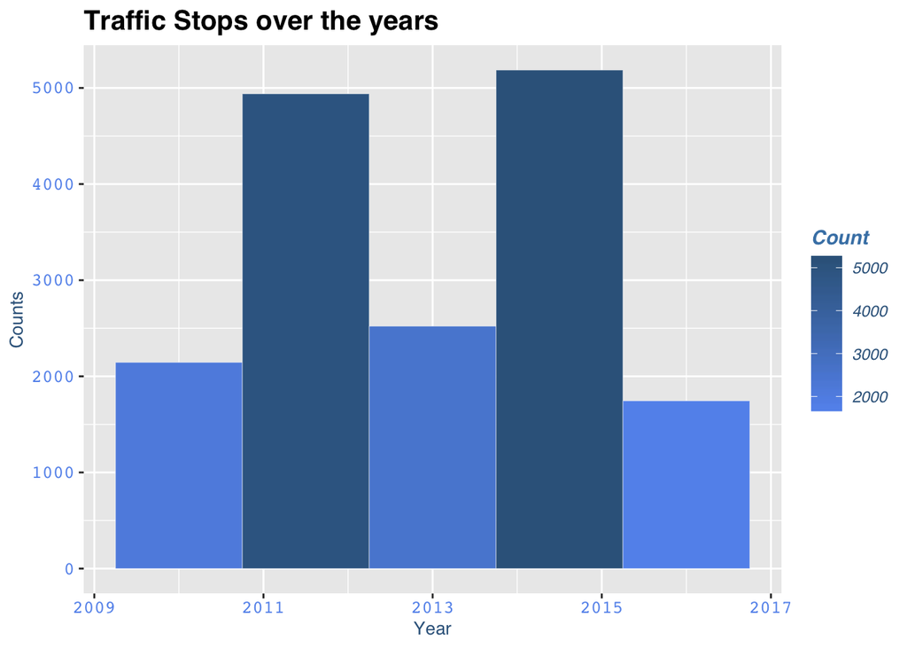

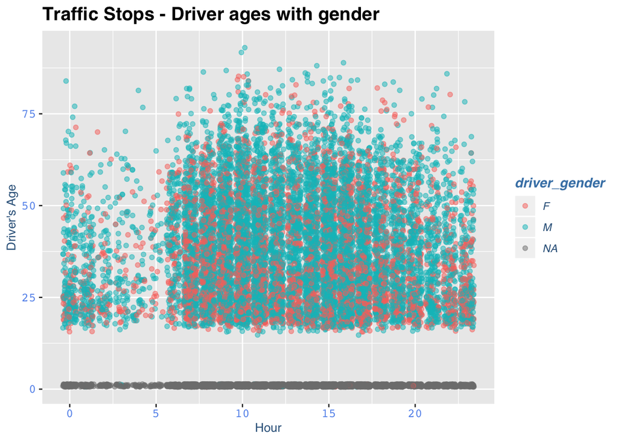

|  | 0 | 1 | 2 | 3 | 4 | 5 | 6 | 7 | 8 | 9 | 10 | 11 | 12 | 13 | 14 | 15 | 16 | 17 | 18 | 19 | 20 | 21 | 22 | 23 |
| --- | --- | --- | --- | --- | --- | --- | --- | --- | --- | --- | --- | --- | --- | --- | --- | --- | --- | --- | --- | --- | --- | --- | --- | --- |
|  | 0 | 0 | 0 | 0 | 0 | 0 | 0 | 0 | 0 | 0 | 0 | 0 | 0 | 0 | 0 | 0 | 0 | 0 | 0 | 0 | 0 | 0 | 0 | 0 |
| F | 60 | 49 | 31 | 24 | 20 | 21 | 84 | 245 | 325 | 285 | 361 | 284 | 221 | 212 | 237 | 307 | 328 | 262 | 190 | 157 | 140 | 69 | 94 | 112 |
| M | 173 | 130 | 71 | 65 | 47 | 28 | 174 | 408 | 554 | 609 | 663 | 555 | 502 | 447 | 583 | 665 | 672 | 526 | 361 | 320 | 284 | 222 | 170 | 173 |

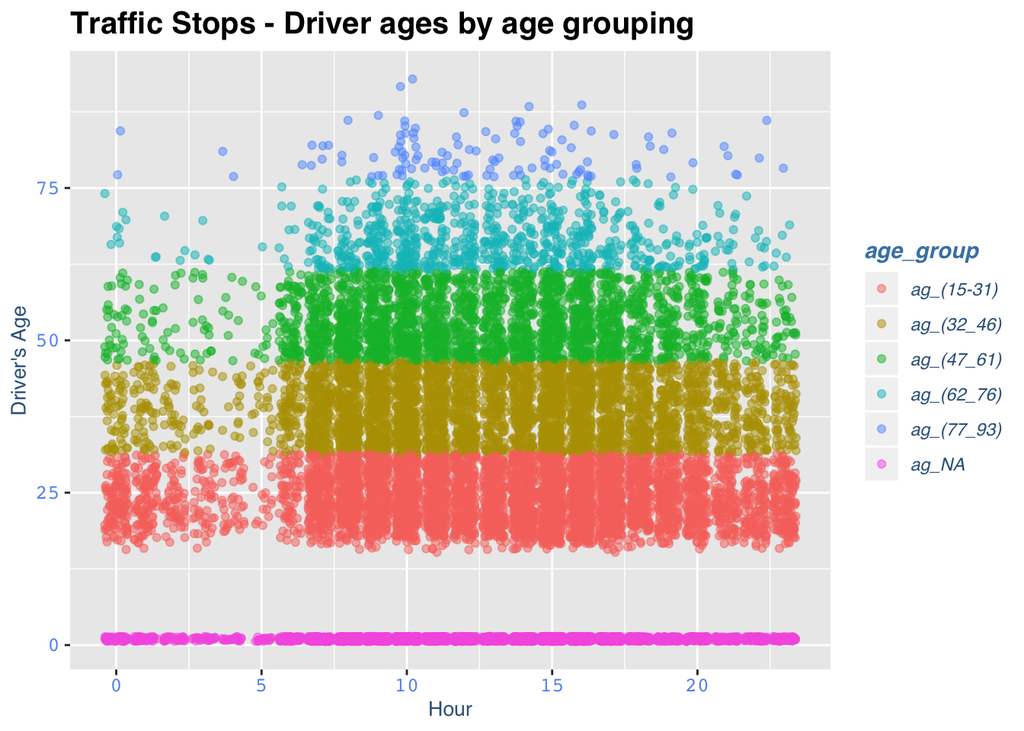

[output not shown]

Based on the sample size, we can infer the following conclusions:

- Gender distribution was comprised as follows:
  - 50% were reported as Male drivers.
  - 26% were reported as Female drivers.
  - The remaining 24% was not captured.
- Age distribution was comprised as follows:
  - 31% of reported drivers were between the ages of 15 to 31.
  - 24% of reported drivers were between the ages of 32 and 46.
  - 16% of reported drivers were between the ages of 47 and 61.
  - 4% of reported drivers were between the ages 62 and 76.
  - 1% of reported drivers were between the ages of 77 and 93.
  - The remaining 24% was not captured.

| hours | Frequency |
| --- | --- |
| 0 | 305 |
| 1 | 228 |
| 2 | 138 |
| 3 | 114 |
| 4 | 88 |
| 5 | 69 |
| 6 | 356 |
| 7 | 898 |
| 8 | 1205 |
| 9 | 1203 |
| 10 | 1349 |
| 11 | 1107 |
| 12 | 964 |
| 13 | 846 |
| 14 | 1076 |
| 15 | 1304 |
| 16 | 1318 |
| 17 | 1046 |
| 18 | 690 |
| 19 | 606 |
| 20 | 532 |
| 21 | 381 |
| 22 | 348 |
| 23 | 365 |

[figure not shown]

[output not shown]

[output not shown]

[output not shown]

[output not shown]

Table continues below

|  | Faulty Equipment Notice |
| --- | --- |
| **DUI** | 0 |
| **DUI,License,Other** | 0 |
| **DUI,License,Truck** | 0 |
| **DUI,Other,Other (non-mapped)** | 0 |
| **DUI,Other,Registration/plates** | 0 |
| **DUI,Other,Safe movement** | 0 |
| **DUI,Paperwork,Safe movement** | 0 |
| **DUI,Registration/plates,Safe movement** | 0 |
| **DUI,Registration/plates,Seat belt** | 0 |
| **DUI,Truck** | 0 |
| **Equipment** | 0.01983 |
| **Equipment,License,Lights** | 0 |
| **Equipment,License,Other,Paperwork,Registration/plates** | 0 |
| **Equipment,License,Paperwork,Registration/plates,Seat belt** | 0 |
| **Equipment,License,Paperwork,Seat belt** | 0 |
| **Equipment,License,Paperwork,Truck** | 0 |
| **Equipment,Other (non-mapped),Speeding** | 0 |
| **Equipment,Paperwork,Safe movement,Speeding** | 0 |
| **License** | 0 |
| **License,Other (non-mapped)** | 0 |
| **License,Other (non-mapped),Safe movement** | 0 |
| **License,Other,Other (non-mapped)** | 0 |
| **License,Other,Other (non-mapped),Safe movement** | 0 |
| **License,Other,Paperwork,Seat belt** | 0 |
| **License,Paperwork,Registration/plates,Safe movement,Truck** | 0 |
| **License,Paperwork,Registration/plates,Speeding,Truck** | 0 |
| **License,Paperwork,Safe movement,Speeding** | 0 |
| **License,Paperwork,Seat belt,Speeding,Truck** | 0 |
| **License,Registration/plates,Speeding,Truck** | 0 |
| **License,Seat belt,Speeding,Truck** | 0 |
| **Lights** | 0 |
| **Lights,Paperwork,Safe movement** | 0 |
| **Lights,Registration/plates,Seat belt** | 0 |
| **Lights,Registration/plates,Speeding** | 0 |
| **Lights,Truck** | 0 |
| **Not Captured** | 0 |
| **Other** | 0.0003024 |
| **Other (non-mapped),Paperwork** | 0 |
| **Other (non-mapped),Registration/plates** | 0 |
| **Other (non-mapped),Safe movement** | 0 |
| **Other,Other (non-mapped),Safe movement** | 0 |
| **Other,Other (non-mapped),Speeding** | 0 |
| **Paperwork** | 0 |
| **Registration** | 0.0003628 |
| **Safe movement** | 6.047e-05 |
| **Seat belt** | 6.047e-05 |
| **Speeding** | 0 |
| **Truck** | 0.0003628 |

Table continues below

|  | Felony Arrest |
| --- | --- |
| **DUI** | 0.0001814 |
| **DUI,License,Other** | 6.047e-05 |
| **DUI,License,Truck** | 0 |
| **DUI,Other,Other (non-mapped)** | 6.047e-05 |
| **DUI,Other,Registration/plates** | 0 |
| **DUI,Other,Safe movement** | 6.047e-05 |
| **DUI,Paperwork,Safe movement** | 0 |
| **DUI,Registration/plates,Safe movement** | 0 |
| **DUI,Registration/plates,Seat belt** | 0 |
| **DUI,Truck** | 0 |
| **Equipment** | 0.0003628 |
| **Equipment,License,Lights** | 0 |
| **Equipment,License,Other,Paperwork,Registration/plates** | 0 |
| **Equipment,License,Paperwork,Registration/plates,Seat belt** | 0 |
| **Equipment,License,Paperwork,Seat belt** | 0 |
| **Equipment,License,Paperwork,Truck** | 0 |
| **Equipment,Other (non-mapped),Speeding** | 0 |
| **Equipment,Paperwork,Safe movement,Speeding** | 0 |
| **License** | 0.00127 |
| **License,Other (non-mapped)** | 0 |
| **License,Other (non-mapped),Safe movement** | 6.047e-05 |
| **License,Other,Other (non-mapped)** | 6.047e-05 |
| **License,Other,Other (non-mapped),Safe movement** | 6.047e-05 |
| **License,Other,Paperwork,Seat belt** | 0 |
| **License,Paperwork,Registration/plates,Safe movement,Truck** | 0 |
| **License,Paperwork,Registration/plates,Speeding,Truck** | 0 |
| **License,Paperwork,Safe movement,Speeding** | 0 |
| **License,Paperwork,Seat belt,Speeding,Truck** | 0 |
| **License,Registration/plates,Speeding,Truck** | 0 |
| **License,Seat belt,Speeding,Truck** | 0 |
| **Lights** | 0 |
| **Lights,Paperwork,Safe movement** | 0 |
| **Lights,Registration/plates,Seat belt** | 0 |
| **Lights,Registration/plates,Speeding** | 0 |
| **Lights,Truck** | 0 |
| **Not Captured** | 0 |
| **Other** | 0.0003024 |
| **Other (non-mapped),Paperwork** | 0 |
| **Other (non-mapped),Registration/plates** | 0 |
| **Other (non-mapped),Safe movement** | 0 |
| **Other,Other (non-mapped),Safe movement** | 0 |
| **Other,Other (non-mapped),Speeding** | 0 |
| **Paperwork** | 0 |
| **Registration** | 6.047e-05 |
| **Safe movement** | 6.047e-05 |
| **Seat belt** | 0 |
| **Speeding** | 0 |
| **Truck** | 0 |

Table continues below

|  | Misdemeanor Arrest |
| --- | --- |
| **DUI** | 0.002056 |
| **DUI,License,Other** | 0 |
| **DUI,License,Truck** | 6.047e-05 |
| **DUI,Other,Other (non-mapped)** | 0 |
| **DUI,Other,Registration/plates** | 6.047e-05 |
| **DUI,Other,Safe movement** | 0 |
| **DUI,Paperwork,Safe movement** | 6.047e-05 |
| **DUI,Registration/plates,Safe movement** | 0.0001814 |
| **DUI,Registration/plates,Seat belt** | 0 |
| **DUI,Truck** | 6.047e-05 |
| **Equipment** | 0.003024 |
| **Equipment,License,Lights** | 0 |
| **Equipment,License,Other,Paperwork,Registration/plates** | 6.047e-05 |
| **Equipment,License,Paperwork,Registration/plates,Seat belt** | 6.047e-05 |
| **Equipment,License,Paperwork,Seat belt** | 6.047e-05 |
| **Equipment,License,Paperwork,Truck** | 0 |
| **Equipment,Other (non-mapped),Speeding** | 0 |
| **Equipment,Paperwork,Safe movement,Speeding** | 0 |
| **License** | 0.01663 |
| **License,Other (non-mapped)** | 0.0001209 |
| **License,Other (non-mapped),Safe movement** | 6.047e-05 |
| **License,Other,Other (non-mapped)** | 6.047e-05 |
| **License,Other,Other (non-mapped),Safe movement** | 0 |
| **License,Other,Paperwork,Seat belt** | 0 |
| **License,Paperwork,Registration/plates,Safe movement,Truck** | 6.047e-05 |
| **License,Paperwork,Registration/plates,Speeding,Truck** | 6.047e-05 |
| **License,Paperwork,Safe movement,Speeding** | 0 |
| **License,Paperwork,Seat belt,Speeding,Truck** | 6.047e-05 |
| **License,Registration/plates,Speeding,Truck** | 0 |
| **License,Seat belt,Speeding,Truck** | 0 |
| **Lights** | 6.047e-05 |
| **Lights,Paperwork,Safe movement** | 0 |
| **Lights,Registration/plates,Seat belt** | 0 |
| **Lights,Registration/plates,Speeding** | 0 |
| **Lights,Truck** | 0 |
| **Not Captured** | 0 |
| **Other** | 0.001572 |
| **Other (non-mapped),Paperwork** | 0 |
| **Other (non-mapped),Registration/plates** | 0 |
| **Other (non-mapped),Safe movement** | 0 |
| **Other,Other (non-mapped),Safe movement** | 0 |
| **Other,Other (non-mapped),Speeding** | 0 |
| **Paperwork** | 0.0008466 |
| **Registration** | 0.0005442 |
| **Safe movement** | 0.0003024 |
| **Seat belt** | 0.0002419 |
| **Speeding** | 0.001028 |
| **Truck** | 0.0001814 |

Table continues below

|  | Not Captured |
| --- | --- |
| **DUI** | 0 |
| **DUI,License,Other** | 0 |
| **DUI,License,Truck** | 0 |
| **DUI,Other,Other (non-mapped)** | 0 |
| **DUI,Other,Registration/plates** | 0 |
| **DUI,Other,Safe movement** | 0 |
| **DUI,Paperwork,Safe movement** | 0 |
| **DUI,Registration/plates,Safe movement** | 0 |
| **DUI,Registration/plates,Seat belt** | 0 |
| **DUI,Truck** | 0 |
| **Equipment** | 0.0001814 |
| **Equipment,License,Lights** | 0 |
| **Equipment,License,Other,Paperwork,Registration/plates** | 0 |
| **Equipment,License,Paperwork,Registration/plates,Seat belt** | 0 |
| **Equipment,License,Paperwork,Seat belt** | 0 |
| **Equipment,License,Paperwork,Truck** | 0 |
| **Equipment,Other (non-mapped),Speeding** | 0 |
| **Equipment,Paperwork,Safe movement,Speeding** | 0 |
| **License** | 0 |
| **License,Other (non-mapped)** | 0 |
| **License,Other (non-mapped),Safe movement** | 0 |
| **License,Other,Other (non-mapped)** | 0 |
| **License,Other,Other (non-mapped),Safe movement** | 0 |
| **License,Other,Paperwork,Seat belt** | 0 |
| **License,Paperwork,Registration/plates,Safe movement,Truck** | 0 |
| **License,Paperwork,Registration/plates,Speeding,Truck** | 0 |
| **License,Paperwork,Safe movement,Speeding** | 0 |
| **License,Paperwork,Seat belt,Speeding,Truck** | 0 |
| **License,Registration/plates,Speeding,Truck** | 0 |
| **License,Seat belt,Speeding,Truck** | 0 |
| **Lights** | 0 |
| **Lights,Paperwork,Safe movement** | 0 |
| **Lights,Registration/plates,Seat belt** | 0 |
| **Lights,Registration/plates,Speeding** | 0 |
| **Lights,Truck** | 0 |
| **Not Captured** | 0.008224 |
| **Other** | 0 |
| **Other (non-mapped),Paperwork** | 0 |
| **Other (non-mapped),Registration/plates** | 0 |
| **Other (non-mapped),Safe movement** | 0 |
| **Other,Other (non-mapped),Safe movement** | 0 |
| **Other,Other (non-mapped),Speeding** | 0 |
| **Paperwork** | 0 |
| **Registration** | 6.047e-05 |
| **Safe movement** | 0.0001814 |
| **Seat belt** | 6.047e-05 |
| **Speeding** | 0.0005442 |
| **Truck** | 0.0005442 |

Table continues below

|  | Warning |
| --- | --- |
| **DUI** | 0 |
| **DUI,License,Other** | 0 |
| **DUI,License,Truck** | 0 |
| **DUI,Other,Other (non-mapped)** | 0 |
| **DUI,Other,Registration/plates** | 0 |
| **DUI,Other,Safe movement** | 0 |
| **DUI,Paperwork,Safe movement** | 0 |
| **DUI,Registration/plates,Safe movement** | 0 |
| **DUI,Registration/plates,Seat belt** | 0 |
| **DUI,Truck** | 0 |
| **Equipment** | 0.03017 |
| **Equipment,License,Lights** | 0 |
| **Equipment,License,Other,Paperwork,Registration/plates** | 0 |
| **Equipment,License,Paperwork,Registration/plates,Seat belt** | 0 |
| **Equipment,License,Paperwork,Seat belt** | 0 |
| **Equipment,License,Paperwork,Truck** | 0 |
| **Equipment,Other (non-mapped),Speeding** | 0 |
| **Equipment,Paperwork,Safe movement,Speeding** | 0 |
| **License** | 0.002237 |
| **License,Other (non-mapped)** | 0 |
| **License,Other (non-mapped),Safe movement** | 0 |
| **License,Other,Other (non-mapped)** | 0 |
| **License,Other,Other (non-mapped),Safe movement** | 0 |
| **License,Other,Paperwork,Seat belt** | 0 |
| **License,Paperwork,Registration/plates,Safe movement,Truck** | 0 |
| **License,Paperwork,Registration/plates,Speeding,Truck** | 0 |
| **License,Paperwork,Safe movement,Speeding** | 0 |
| **License,Paperwork,Seat belt,Speeding,Truck** | 0 |
| **License,Registration/plates,Speeding,Truck** | 0 |
| **License,Seat belt,Speeding,Truck** | 0 |
| **Lights** | 0.003568 |
| **Lights,Paperwork,Safe movement** | 0 |
| **Lights,Registration/plates,Seat belt** | 0 |
| **Lights,Registration/plates,Speeding** | 0 |
| **Lights,Truck** | 0.0001209 |
| **Not Captured** | 0.01971 |
| **Other** | 0.007498 |
| **Other (non-mapped),Paperwork** | 0 |
| **Other (non-mapped),Registration/plates** | 0 |
| **Other (non-mapped),Safe movement** | 6.047e-05 |
| **Other,Other (non-mapped),Safe movement** | 0 |
| **Other,Other (non-mapped),Speeding** | 0 |
| **Paperwork** | 0.003265 |
| **Registration** | 0.009071 |
| **Safe movement** | 0.03163 |
| **Seat belt** | 0.002721 |
| **Speeding** | 0.0904 |
| **Truck** | 0.003084 |

Looking at the violations to outcomes, we can infer the following: * Speeding appears as the most reported reason for traffic stops at 37%. * Citations appear as the most reported outcome at 73%.

## Logistic Regression.

Having created our outcome/response variable (is_citation) earlier during the data preparation phase, we are now ready to create the Logistic Regression model:

```r
stop.final2 <- na.omit(stop.final)
stop.lr <- glm(is_citation ~ stop_year + driver_age + violation_rawsl + driver_gender, data = stop.final2, family = "binomial")

pander(summary(stop.lr))
```

Table continues below

|  | Estimate |
| --- | --- |
| **(Intercept)** | -111.3 |
| **stop_year** | 0.05507 |
| **driver_age** | -0.01451 |
| **violation_rawslDUI,License,Other** | -12.75 |
| **violation_rawslDUI,License,Truck** | -12.76 |
| **violation_rawslDUI,Other,Other (non-mapped)** | -12.81 |
| **violation_rawslDUI,Other,Registration/plates** | -13.02 |
| **violation_rawslDUI,Other,Safe movement** | -12.96 |
| **violation_rawslDUI,Registration/plates,Safe movement** | -13 |
| **violation_rawslDUI,Registration/plates,Seat belt** | 14.78 |
| **violation_rawslDUI,Truck** | -12.97 |
| **violation_rawslEquipment** | 1.104 |
| **violation_rawslEquipment,License,Lights** | 14.39 |
| **violation_rawslEquipment,License,Other,Paperwork,Registration/plates** | 0.8511 |
| **violation_rawslEquipment,License,Paperwork,Registration/plates,Seat belt** | 0.9354 |
| **violation_rawslEquipment,License,Paperwork,Seat belt** | 1.426 |
| **violation_rawslEquipment,License,Paperwork,Truck** | 14.51 |
| **violation_rawslEquipment,Paperwork,Safe movement,Speeding** | 14.31 |
| **violation_rawslLicense** | 1.732 |
| **violation_rawslLicense,Other (non-mapped)** | -12.83 |
| **violation_rawslLicense,Other (non-mapped),Safe movement** | 0.6984 |
| **violation_rawslLicense,Other,Other (non-mapped)** | -12.72 |
| **violation_rawslLicense,Other,Other (non-mapped),Safe movement** | -12.69 |
| **violation_rawslLicense,Other,Paperwork,Seat belt** | 14.53 |
| **violation_rawslLicense,Paperwork,Registration/plates,Speeding,Truck** | -12.77 |
| **violation_rawslLicense,Registration/plates,Speeding,Truck** | 14.49 |
| **violation_rawslLicense,Seat belt,Speeding,Truck** | 14.72 |
| **violation_rawslLights** | -0.1337 |
| **violation_rawslLights,Paperwork,Safe movement** | 14.48 |
| **violation_rawslLights,Registration/plates,Seat belt** | 14.39 |
| **violation_rawslLights,Registration/plates,Speeding** | 14.19 |
| **violation_rawslLights,Truck** | 1.666 |
| **violation_rawslNot Captured** | 1.567 |
| **violation_rawslOther** | 1.742 |
| **violation_rawslOther (non-mapped),Paperwork** | 14.55 |
| **violation_rawslOther (non-mapped),Registration/plates** | 14.5 |
| **violation_rawslOther,Other (non-mapped),Safe movement** | 14.57 |
| **violation_rawslPaperwork** | 3.936 |
| **violation_rawslRegistration** | 2.382 |
| **violation_rawslSafe movement** | 1.576 |
| **violation_rawslSeat belt** | 3.755 |
| **violation_rawslSpeeding** | 2.071 |
| **violation_rawslTruck** | 3.195 |
| **driver_genderM** | 0.1732 |

Table continues below

|  | Std. Error |
| --- | --- |
| **(Intercept)** | 27.43 |
| **stop_year** | 0.01363 |
| **driver_age** | 0.001458 |
| **violation_rawslDUI,License,Other** | 535.4 |
| **violation_rawslDUI,License,Truck** | 535.4 |
| **violation_rawslDUI,Other,Other (non-mapped)** | 535.4 |
| **violation_rawslDUI,Other,Registration/plates** | 535.4 |
| **violation_rawslDUI,Other,Safe movement** | 535.4 |
| **violation_rawslDUI,Registration/plates,Safe movement** | 378.6 |
| **violation_rawslDUI,Registration/plates,Seat belt** | 535.4 |
| **violation_rawslDUI,Truck** | 535.4 |
| **violation_rawslEquipment** | 0.3376 |
| **violation_rawslEquipment,License,Lights** | 535.4 |
| **violation_rawslEquipment,License,Other,Paperwork,Registration/plates** | 1.453 |
| **violation_rawslEquipment,License,Paperwork,Registration/plates,Seat belt** | 1.456 |
| **violation_rawslEquipment,License,Paperwork,Seat belt** | 1.27 |
| **violation_rawslEquipment,License,Paperwork,Truck** | 535.4 |
| **violation_rawslEquipment,Paperwork,Safe movement,Speeding** | 378.3 |
| **violation_rawslLicense** | 0.3418 |
| **violation_rawslLicense,Other (non-mapped)** | 378.6 |
| **violation_rawslLicense,Other (non-mapped),Safe movement** | 1.453 |
| **violation_rawslLicense,Other,Other (non-mapped)** | 535.4 |
| **violation_rawslLicense,Other,Other (non-mapped),Safe movement** | 535.4 |
| **violation_rawslLicense,Other,Paperwork,Seat belt** | 535.4 |
| **violation_rawslLicense,Paperwork,Registration/plates,Speeding,Truck** | 535.4 |
| **violation_rawslLicense,Registration/plates,Speeding,Truck** | 535.4 |
| **violation_rawslLicense,Seat belt,Speeding,Truck** | 535.4 |
| **violation_rawslLights** | 0.4563 |
| **violation_rawslLights,Paperwork,Safe movement** | 535.4 |
| **violation_rawslLights,Registration/plates,Seat belt** | 535.4 |
| **violation_rawslLights,Registration/plates,Speeding** | 535.4 |
| **violation_rawslLights,Truck** | 1.273 |
| **violation_rawslNot Captured** | 0.3388 |
| **violation_rawslOther** | 0.3507 |
| **violation_rawslOther (non-mapped),Paperwork** | 535.4 |
| **violation_rawslOther (non-mapped),Registration/plates** | 535.4 |
| **violation_rawslOther,Other (non-mapped),Safe movement** | 535.4 |
| **violation_rawslPaperwork** | 0.3652 |
| **violation_rawslRegistration** | 0.3493 |
| **violation_rawslSafe movement** | 0.34 |
| **violation_rawslSeat belt** | 0.3713 |
| **violation_rawslSpeeding** | 0.3356 |
| **violation_rawslTruck** | 0.3652 |
| **driver_genderM** | 0.04535 |

Table continues below

|  | z value |
| --- | --- |
| **(Intercept)** | -4.058 |
| **stop_year** | 4.04 |
| **driver_age** | -9.954 |
| **violation_rawslDUI,License,Other** | -0.02381 |
| **violation_rawslDUI,License,Truck** | -0.02383 |
| **violation_rawslDUI,Other,Other (non-mapped)** | -0.02392 |
| **violation_rawslDUI,Other,Registration/plates** | -0.02432 |
| **violation_rawslDUI,Other,Safe movement** | -0.0242 |
| **violation_rawslDUI,Registration/plates,Safe movement** | -0.03435 |
| **violation_rawslDUI,Registration/plates,Seat belt** | 0.0276 |
| **violation_rawslDUI,Truck** | -0.02422 |
| **violation_rawslEquipment** | 3.269 |
| **violation_rawslEquipment,License,Lights** | 0.02687 |
| **violation_rawslEquipment,License,Other,Paperwork,Registration/plates** | 0.5856 |
| **violation_rawslEquipment,License,Paperwork,Registration/plates,Seat belt** | 0.6426 |
| **violation_rawslEquipment,License,Paperwork,Seat belt** | 1.122 |
| **violation_rawslEquipment,License,Paperwork,Truck** | 0.02709 |
| **violation_rawslEquipment,Paperwork,Safe movement,Speeding** | 0.03782 |
| **violation_rawslLicense** | 5.069 |
| **violation_rawslLicense,Other (non-mapped)** | -0.03388 |
| **violation_rawslLicense,Other (non-mapped),Safe movement** | 0.4805 |
| **violation_rawslLicense,Other,Other (non-mapped)** | -0.02377 |
| **violation_rawslLicense,Other,Other (non-mapped),Safe movement** | -0.02369 |
| **violation_rawslLicense,Other,Paperwork,Seat belt** | 0.02714 |
| **violation_rawslLicense,Paperwork,Registration/plates,Speeding,Truck** | -0.02385 |
| **violation_rawslLicense,Registration/plates,Speeding,Truck** | 0.02706 |
| **violation_rawslLicense,Seat belt,Speeding,Truck** | 0.02749 |
| **violation_rawslLights** | -0.293 |
| **violation_rawslLights,Paperwork,Safe movement** | 0.02705 |
| **violation_rawslLights,Registration/plates,Seat belt** | 0.02688 |
| **violation_rawslLights,Registration/plates,Speeding** | 0.0265 |
| **violation_rawslLights,Truck** | 1.309 |
| **violation_rawslNot Captured** | 4.626 |
| **violation_rawslOther** | 4.967 |
| **violation_rawslOther (non-mapped),Paperwork** | 0.02718 |
| **violation_rawslOther (non-mapped),Registration/plates** | 0.02707 |
| **violation_rawslOther,Other (non-mapped),Safe movement** | 0.02722 |
| **violation_rawslPaperwork** | 10.78 |
| **violation_rawslRegistration** | 6.82 |
| **violation_rawslSafe movement** | 4.637 |
| **violation_rawslSeat belt** | 10.11 |
| **violation_rawslSpeeding** | 6.17 |
| **violation_rawslTruck** | 8.75 |
| **driver_genderM** | 3.818 |

|  | Pr(>\|z\|) |
| --- | --- |
| **(Intercept)** | 4.951e-05 |
| **stop_year** | 5.336e-05 |
| **driver_age** | 2.426e-23 |
| **violation_rawslDUI,License,Other** | 0.981 |
| **violation_rawslDUI,License,Truck** | 0.981 |
| **violation_rawslDUI,Other,Other (non-mapped)** | 0.9809 |
| **violation_rawslDUI,Other,Registration/plates** | 0.9806 |
| **violation_rawslDUI,Other,Safe movement** | 0.9807 |
| **violation_rawslDUI,Registration/plates,Safe movement** | 0.9726 |
| **violation_rawslDUI,Registration/plates,Seat belt** | 0.978 |
| **violation_rawslDUI,Truck** | 0.9807 |
| **violation_rawslEquipment** | 0.001081 |
| **violation_rawslEquipment,License,Lights** | 0.9786 |
| **violation_rawslEquipment,License,Other,Paperwork,Registration/plates** | 0.5581 |
| **violation_rawslEquipment,License,Paperwork,Registration/plates,Seat belt** | 0.5205 |
| **violation_rawslEquipment,License,Paperwork,Seat belt** | 0.2617 |
| **violation_rawslEquipment,License,Paperwork,Truck** | 0.9784 |
| **violation_rawslEquipment,Paperwork,Safe movement,Speeding** | 0.9698 |
| **violation_rawslLicense** | 4.008e-07 |
| **violation_rawslLicense,Other (non-mapped)** | 0.973 |
| **violation_rawslLicense,Other (non-mapped),Safe movement** | 0.6309 |
| **violation_rawslLicense,Other,Other (non-mapped)** | 0.981 |
| **violation_rawslLicense,Other,Other (non-mapped),Safe movement** | 0.9811 |
| **violation_rawslLicense,Other,Paperwork,Seat belt** | 0.9783 |
| **violation_rawslLicense,Paperwork,Registration/plates,Speeding,Truck** | 0.981 |
| **violation_rawslLicense,Registration/plates,Speeding,Truck** | 0.9784 |
| **violation_rawslLicense,Seat belt,Speeding,Truck** | 0.9781 |
| **violation_rawslLights** | 0.7695 |
| **violation_rawslLights,Paperwork,Safe movement** | 0.9784 |
| **violation_rawslLights,Registration/plates,Seat belt** | 0.9786 |
| **violation_rawslLights,Registration/plates,Speeding** | 0.9789 |
| **violation_rawslLights,Truck** | 0.1906 |
| **violation_rawslNot Captured** | 3.724e-06 |
| **violation_rawslOther** | 6.795e-07 |
| **violation_rawslOther (non-mapped),Paperwork** | 0.9783 |
| **violation_rawslOther (non-mapped),Registration/plates** | 0.9784 |
| **violation_rawslOther,Other (non-mapped),Safe movement** | 0.9783 |
| **violation_rawslPaperwork** | 4.342e-27 |
| **violation_rawslRegistration** | 9.136e-12 |
| **violation_rawslSafe movement** | 3.541e-06 |
| **violation_rawslSeat belt** | 4.814e-24 |
| **violation_rawslSpeeding** | 6.813e-10 |
| **violation_rawslTruck** | 2.139e-18 |
| **driver_genderM** | 0.0001344 |

(Dispersion parameter for binomial family taken to be 1 )

| Null deviance: | 14401 on 12513 degrees of freedom |
| --- | --- |
| Residual deviance: | 13150 on 12470 degrees of freedom |

**Important** *R will automatically discard any rows with NA values. As such, we have to infer that the this model and it’s accuracy will only apply to any and all complete observations. I still went ahead and omitted the data myself and saved it into a new data frame.*

```r
wald.test(b = coef(stop.lr), Sigma = vcov(stop.lr), Terms = 4:15)
```

```
## Wald test:
## ----------
##
## Chi-squared test:
## X2 = 10.7, df = 12, P(> X2) = 0.55
```

Lastly, we test the accuracy of this model by using the area under the curve method:

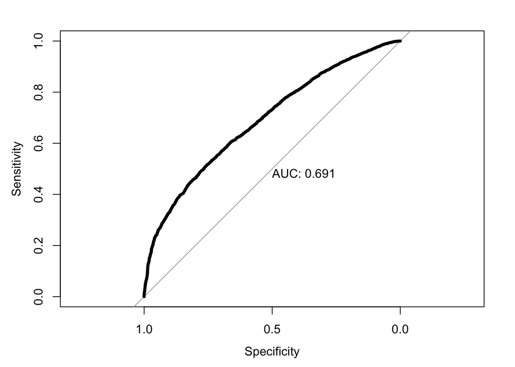

```
##
## Call:
## roc.default(response = stop.final2$is_citation, predictor = stop.lr$fitted.values,     plot = TRUE, lwd = 4, print.auc = TRUE)
##
## Data: stop.lr$fitted.values in 3282 controls (stop.final2$is_citation 0) < 9232 cases (stop.final2$is_citation 1).
## Area under the curve: 0.6906
```

```r
stop_roc <-roc(stop.final2$is_citation, stop.lr$fitted.values)
roc(stop.final2$is_citation, stop.lr$fitted.values, plot=TRUE, lwd = 4, print.auc =TRUE)
```

```r
auc(stop_roc)
```

```
## Area under the curve: 0.6906
```

AUC = 0.69

```r
pander(vif(stop.lr))
```

|  | GVIF | Df | GVIF^(1/(2*Df)) |
| --- | --- | --- | --- |
| **stop_year** | 1.034 | 1 | 1.017 |
| **driver_age** | 1.043 | 1 | 1.021 |
| **violation_rawsl** | 1.073 | 40 | 1.001 |
| **driver_gender** | 1.021 | 1 | 1.011 |

```r
pander(1/vif(stop.lr))
```

|  | GVIF | Df | GVIF^(1/(2*Df)) |
| --- | --- | --- | --- |
| **stop_year** | 0.967 | 1 | 0.9834 |
| **driver_age** | 0.9587 | 1 | 0.9791 |
| **violation_rawsl** | 0.9319 | 0.025 | 0.9991 |
| **driver_gender** | 0.979 | 1 | 0.9894 |

None of the VIF values exceed 10, meaning this model presents no apparent evidence of collinearity.

## Machine Learning - Naive Bayes

```r
stop.final2 <- na.omit(stop.final)
keep3 <- c("stop_outcome","driver_age","stop_year", "driver_gender","violation_rawsl")
stop.final3 <- stop.final2[,keep3]

set.seed(123)
stop.subset <- stop.final3[,1:5]
stop.dat <- sample(1:nrow(stop.subset), size=nrow(stop.subset)*0.7, replace = FALSE)
train.stop <- na.omit(stop.final3[stop.dat,])
test.stop<- na.omit(stop.final3[-stop.dat,])
stop_nb <- naiveBayes(as.factor(stop_outcome) ~ driver_age + driver_gender + stop_year  + as.factor(violation_rawsl), data = train.stop)
stop_nb
```

```
##
## Naive Bayes Classifier for Discrete Predictors
##
## Call:
## naiveBayes.default(x = X, y = Y, laplace = laplace)
##
## A-priori probabilities:
## Y
##                Citation Faulty Equipment Notice           Felony Arrest
##             0.738212125             0.021235301             0.002854207
##      Misdemeanor Arrest            Not Captured                 Warning
##             0.027400388             0.011188492             0.199109487
##
## Conditional probabilities:
##                          driver_age
## Y                             [,1]      [,2]
##   Citation                37.15002 14.399517
##   Faulty Equipment Notice 38.35484 14.020175
##   Felony Arrest           33.96000  8.941849
##   Misdemeanor Arrest      32.56667 11.266445
##   Not Captured            38.38776 14.826580
##   Warning                 40.45011 15.403497
##
##                          driver_gender
## Y                                           F         M
##   Citation                0.0000000 0.3221466 0.6778534
##   Faulty Equipment Notice 0.0000000 0.3118280 0.6881720
##   Felony Arrest           0.0000000 0.2000000 0.8000000
##   Misdemeanor Arrest      0.0000000 0.2375000 0.7625000
##   Not Captured            0.0000000 0.3877551 0.6122449
##   Warning                 0.0000000 0.3853211 0.6146789
##
##                          stop_year
## Y                             [,1]     [,2]
##   Citation                2012.449 1.594066
##   Faulty Equipment Notice 2012.269 1.486078
##   Felony Arrest           2012.360 1.254326
##   Misdemeanor Arrest      2012.296 1.536169
##   Not Captured            2011.806 1.215520
##   Warning                 2012.370 1.593960
```

[output cut: 274 more lines]

```
## Y                         Registration Safe movement    Seat belt
##   Citation                0.0553665326  0.0754716981 0.0762449737
##   Faulty Equipment Notice 0.0215053763  0.0053763441 0.0053763441
##   Felony Arrest           0.0000000000  0.0400000000 0.0000000000
##   Misdemeanor Arrest      0.0166666667  0.0125000000 0.0125000000
##   Not Captured            0.0000000000  0.0102040816 0.0000000000
##   Warning                 0.0464449541  0.1462155963 0.0114678899
##                          as.factor(violation_rawsl)
## Y                             Speeding        Truck
##   Citation                0.3533869471 0.0525827405
##   Faulty Equipment Notice 0.0000000000 0.0215053763
##   Felony Arrest           0.0000000000 0.0000000000
##   Misdemeanor Arrest      0.0375000000 0.0041666667
##   Not Captured            0.0510204082 0.0408163265
##   Warning                 0.4145642202 0.0149082569
```

```r
prestop <- predict(stop_nb, test.stop)
confusionMatrix(table(prestop, test.stop$stop_outcome))
```

```
## Confusion Matrix and Statistics
##
##
## prestop                   Citation Faulty Equipment Notice Felony Arrest
##   Citation                    2764                      83            12
##   Faulty Equipment Notice        0                       0             0
##   Felony Arrest                  0                       0             0
##   Misdemeanor Arrest             0                       0             0
##   Not Captured                   0                       0             0
##   Warning                        2                       0             0
##
## prestop                   Misdemeanor Arrest Not Captured Warning
##   Citation                                97           56     739
##   Faulty Equipment Notice                  0            0       0
##   Felony Arrest                            0            0       0
##   Misdemeanor Arrest                       0            0       0
##   Not Captured                             0            0       0
##   Warning                                  0            0       2
##
## Overall Statistics
##
##                Accuracy : 0.7366
##                  95% CI : (0.7222, 0.7507)
##     No Information Rate : 0.7366
##     P-Value [Acc > NIR] : 0.5086
##
##                   Kappa : 0.0022
##
##  Mcnemar's Test P-Value : NA
##
## Statistics by Class:
##
##                      Class: Citation Class: Faulty Equipment Notice
## Sensitivity                 0.999277                         0.0000
## Specificity                 0.002022                         1.0000
## Pos Pred Value              0.736870                            NaN
## Neg Pred Value              0.500000                         0.9779
## Prevalence                  0.736618                         0.0221
## Detection Rate              0.736085                         0.0000
## Detection Prevalence        0.998935                         0.0000
## Balanced Accuracy           0.500650                         0.5000
##                      Class: Felony Arrest Class: Misdemeanor Arrest
## Sensitivity                      0.000000                   0.00000
## Specificity                      1.000000                   1.00000
## Pos Pred Value                        NaN                       NaN
## Neg Pred Value                   0.996804                   0.97417
## Prevalence                       0.003196                   0.02583
## Detection Rate                   0.000000                   0.00000
## Detection Prevalence             0.000000                   0.00000
## Balanced Accuracy                0.500000                   0.50000
##                      Class: Not Captured Class: Warning
## Sensitivity                      0.00000      0.0026991
## Specificity                      1.00000      0.9993364
## Pos Pred Value                       NaN      0.5000000
## Neg Pred Value                   0.98509      0.8029859
## Prevalence                       0.01491      0.1973369
## Detection Rate                   0.00000      0.0005326
## Detection Prevalence             0.00000      0.0010652
## Balanced Accuracy                0.50000      0.5010177
```

## Insights and Conclusions

**Conclusions and Next Steps - What could’ve been.**

After getting to this point, I went back to the Step 1 and Step 2 documents of this final project to see if this final study is on track with what was previously established. Unsurprisingly, it is not. As I delved into this step, I reconsidered some of my research questions such as trying to gauge driver race demographics, police officer data and regional data. It does not mean these aspects of the data were worth pursuing, but rather more information would be needed to provided better context - Such as getting population data for the various counties in the state of Florida to gauge race demographics in the area as a contrast to the driver race data. The missing data is certainly a cause for concern, however it helps illustrate a good point that perhaps my data sample selection was perhaps not the best or rather as a true representation of the total data available, we need to do more research as to the root cause of this.

Does this research provide an answer the question that was asked at the very beginning of this document? - the same one that happened to crawl in my head as I watched someone else get a citation for speeding? At the very least, I have some context that will allow me to continue to further research the matter and see if I can get a more definitive answer that uses a more robust data set without so many null values.